# AS8

Sai Ananthula

2023-04-10

```r
library(tidyverse)
library(e1071)
```

## 5

5a

```r
x1 <- runif (500) - 0.5
x2 <- runif (500) - 0.5
y <- 1 * (x1^2 - x2^2 > 0)
```

5b

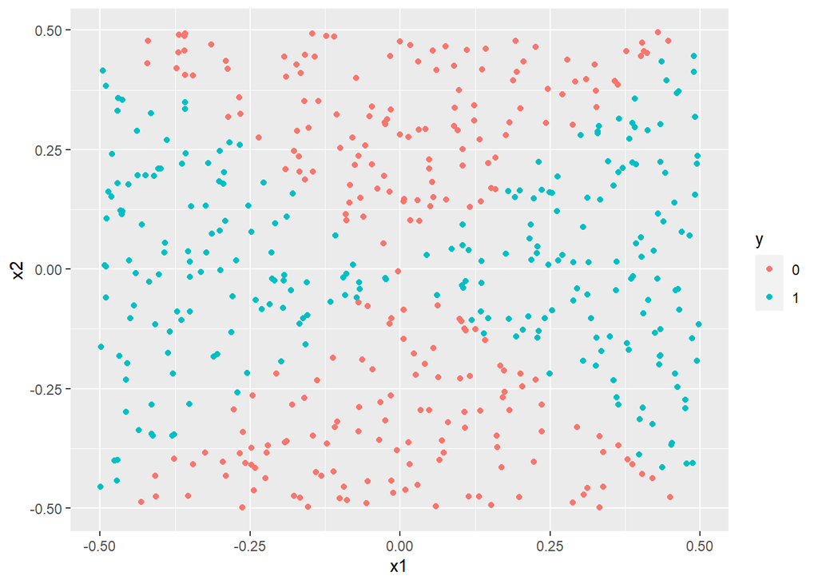

```r
data = data.frame(x1 = x1, x2 = x2, y = as.factor(y))

ggplot(data, aes(x1,x2,color = y)) +
  geom_point()
```

```r
log <- glm(y~., data= data, family = binomial)

summary(log)
```

```
##
## Call:
## glm(formula = y ~ ., family = binomial, data = data)
##
## Deviance Residuals:
##      Min        1Q    Median        3Q       Max
## -1.22102  -1.17763  -0.00013   1.17313   1.22541
##
## Coefficients:
##              Estimate Std. Error z value Pr(>|z|)
## (Intercept) -0.002214   0.089563  -0.025    0.980
## x1           0.145294   0.310174   0.468    0.639
## x2           0.082187   0.314187   0.262    0.794
##
## (Dispersion parameter for binomial family taken to be 1)
##
##     Null deviance: 693.15  on 499  degrees of freedom
## Residual deviance: 692.85  on 497  degrees of freedom
## AIC: 698.85
##
## Number of Fisher Scoring iterations: 3
```

No predictors are significant.

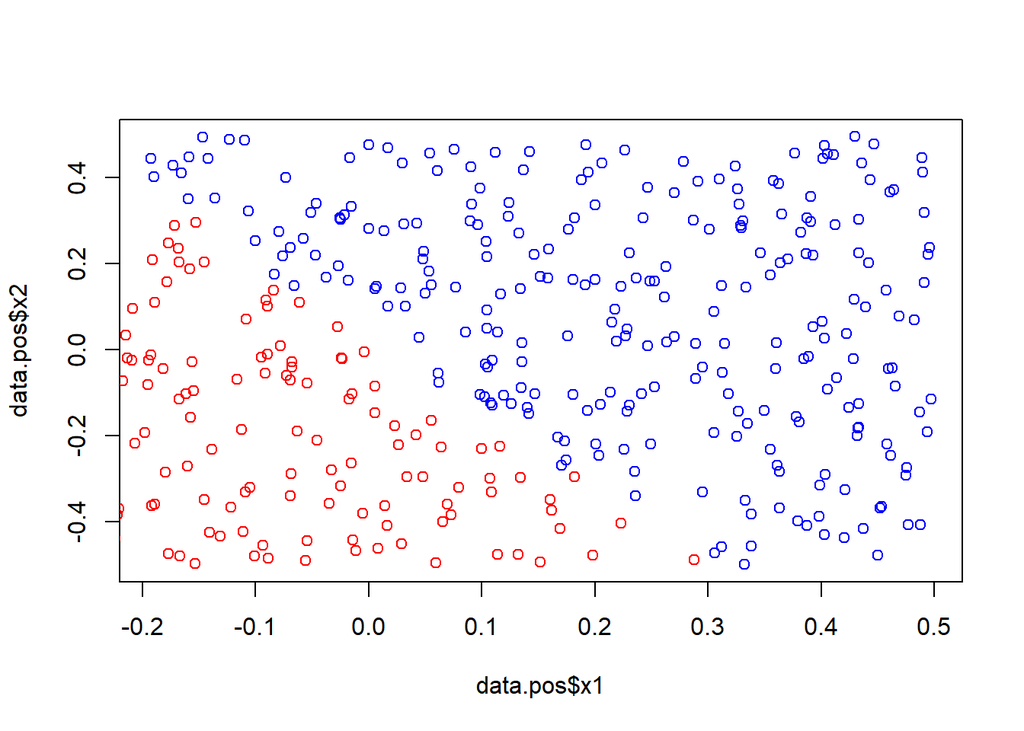

```r
probs <- predict(log, data = data, type = "response")
preds <- ifelse(probs > 0.5, 1, 0)


data.neg = data[preds==0,]
data.pos = data[preds==1,]

plot(data.pos$x1, data.pos$x2, col=("blue"))
 points(data.neg$x1, data.neg$x2, col=("red"))
```

The decision boundary is linear.

```r
log2 <- glm(y ~ poly(x1,2) + poly(x2,2), data= data, family = binomial)
summary(log2)
```

```
##
## Call:
## glm(formula = y ~ poly(x1, 2) + poly(x2, 2), family = binomial,
##     data = data)
##
## Deviance Residuals:
##       Min         1Q     Median         3Q        Max
## -0.007923   0.000000   0.000000   0.000000   0.009387
##
## Coefficients:
##               Estimate Std. Error z value Pr(>|z|)
## (Intercept)      316.9    10971.5   0.029    0.977
## poly(x1, 2)1    2612.2    30499.0   0.086    0.932
## poly(x1, 2)2  250175.4  1919227.6   0.130    0.896
## poly(x2, 2)1   11498.6   133809.7   0.086    0.932
## poly(x2, 2)2 -247206.5  1799437.0  -0.137    0.891
##
## (Dispersion parameter for binomial family taken to be 1)
##
##     Null deviance: 6.9315e+02  on 499  degrees of freedom
## Residual deviance: 1.6880e-04  on 495  degrees of freedom
## AIC: 10
##
## Number of Fisher Scoring iterations: 25
```

No predictors are statistically significant.

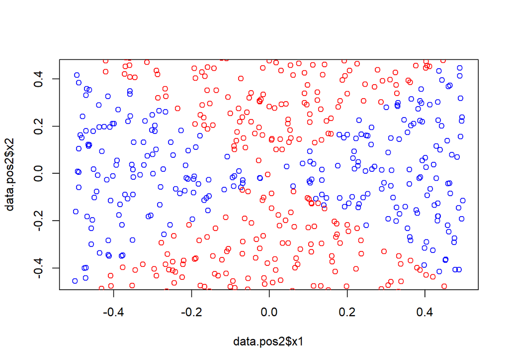

```r
probs2 <- predict(log2, data = data, family = binomial)
preds2 <- ifelse(probs2 > 0.5, 1, 0)


data.neg2 = data[preds2==0,]
data.pos2 = data[preds2==1,]

plot(data.pos2$x1, data.pos2$x2, col=("blue"))
 points(data.neg2$x1, data.neg2$x2, col=("red"))
```

The decision boundary is no obviously non-linear.

5g.

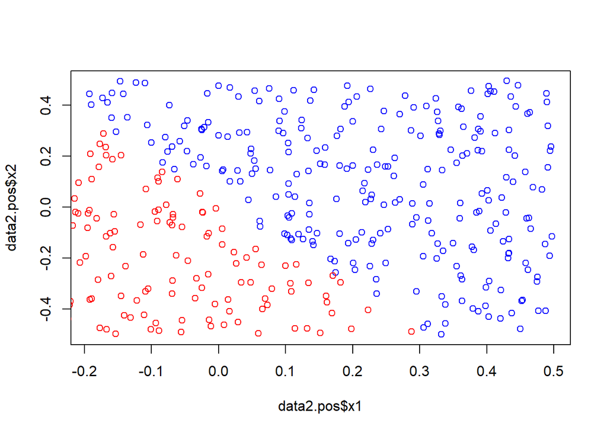

```r
svm_model <- svm(y ~ x1 + x2, data, kernel = "linear", cost = 0.01)

preds3 <- predict(svm_model, data)

data2.neg = data[preds3==0,]
data2.pos = data[preds3==1,]

plot(data2.pos$x1, data2.pos$x2, col = ("blue"))
points(data2.neg$x1, data2.neg$x2, col = ("red"))
```

5h.

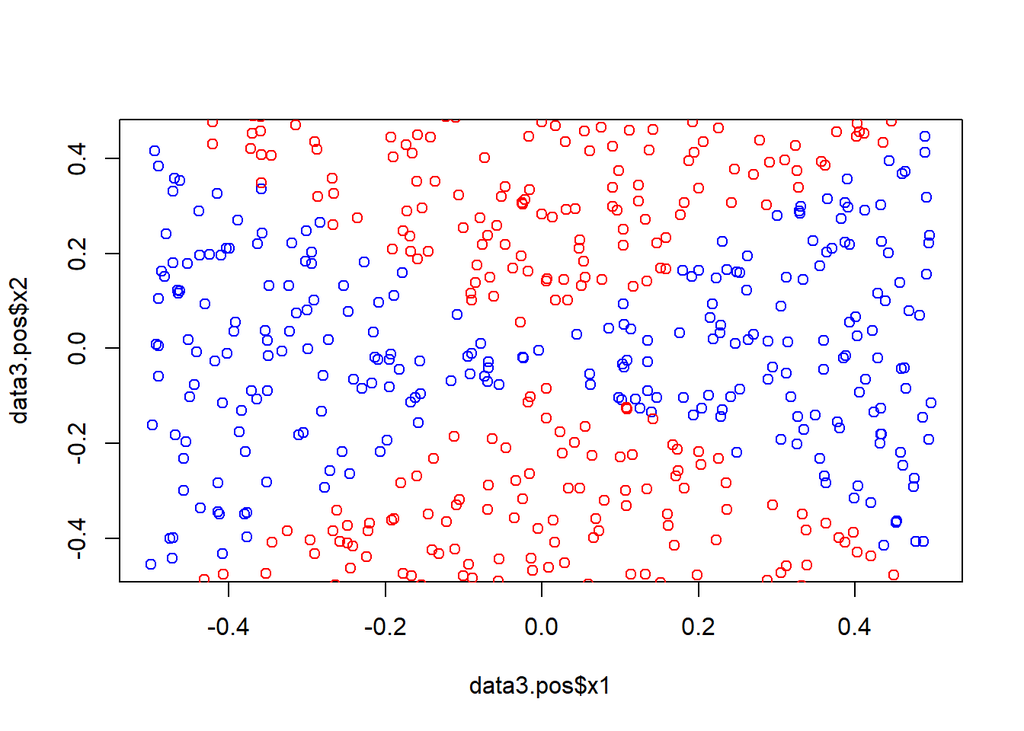

```r
radial <- svm(y ~ x1 + x2, data = data, kernel = "radial")
radial_preds = predict(radial, data)

data3.neg = data[radial_preds==0,]
data3.pos = data[radial_preds ==1,]

plot(data3.pos$x1, data3.pos$x2, col = ("blue"))
points(data3.neg$x1, data3.neg$x2, col = ("red"))
```

5i. The radial svm is very similar to the true decision boundary due to its non-linearity.

## 7

```r
library(ISLR2)
```

```r
gas_bin <- ifelse(Auto$mpg > median(Auto$mpg), 1, 0)

Auto$mpg_tier <- as.factor(gas_bin)
```

```r
set.seed(715)
svm_model <- tune(svm, mpg_tier ~ ., data = Auto, kernel = "linear",
                 ranges = list(cost = c(0.01, 0.1, 1, 10, 100,1000)))

summary(svm_model)
```

```
##
## Parameter tuning of 'svm':
##
## - sampling method: 10-fold cross validation
##
## - best parameters:
##  cost
##     1
##
## - best performance: 0.01019231
##
## - Detailed performance results:
##    cost      error dispersion
## 1 1e-02 0.07403846 0.04908511
## 2 1e-01 0.04339744 0.03430276
## 3 1e+00 0.01019231 0.01315951
## 4 1e+01 0.01532051 0.01318724
## 5 1e+02 0.03070513 0.02912331
## 6 1e+03 0.03070513 0.02912331
```

```r
radial_Auto <- tune(svm, mpg_tier ~ ., data = Auto, kernel = "radial",
                 ranges = list(cost = c(0.01, 0.1, 1, 10, 100,1000),
                               gamma = c(0.001, 0.01, 0.1, 1, 10)))

poly_Auto <- tune(svm, mpg_tier ~ ., data = Auto, kernel = "polynomial",
                 ranges = list(cost = c(0.01, 0.1, 1, 10, 100,1000),
                               degree = c(2, 3, 4, 5)))
```

```r
radial_Auto$performances[which.min(radial_Auto$performances$error),]
```

```
##   cost gamma      error dispersion
## 6 1000 0.001 0.01262821  0.0214997
```

```r
poly_Auto$performances[which.min(poly_Auto$performances$error),]
```

```
##    cost degree     error dispersion
## 12 1000      3 0.2524359 0.08149843
```

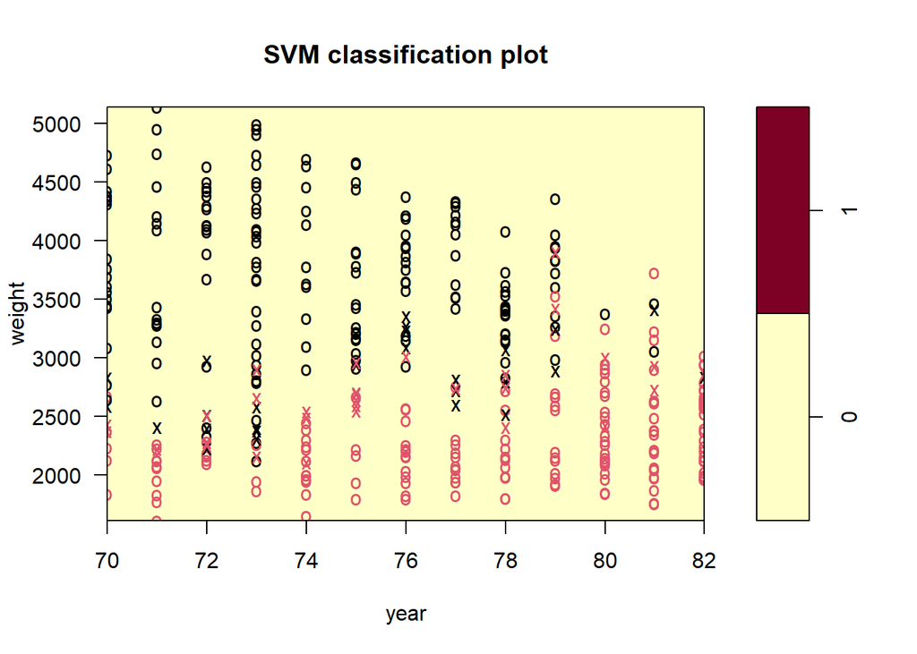

```r
plot(svm_model$best.model, Auto, weight ~ year)
```

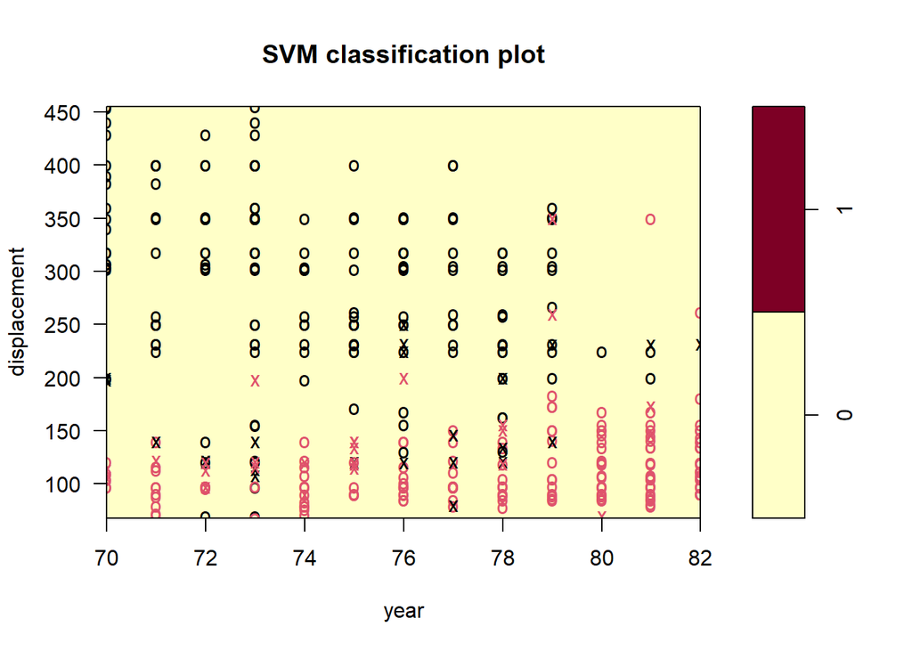

```r
plot(radial_Auto$best.model, Auto, displacement ~ year)
```

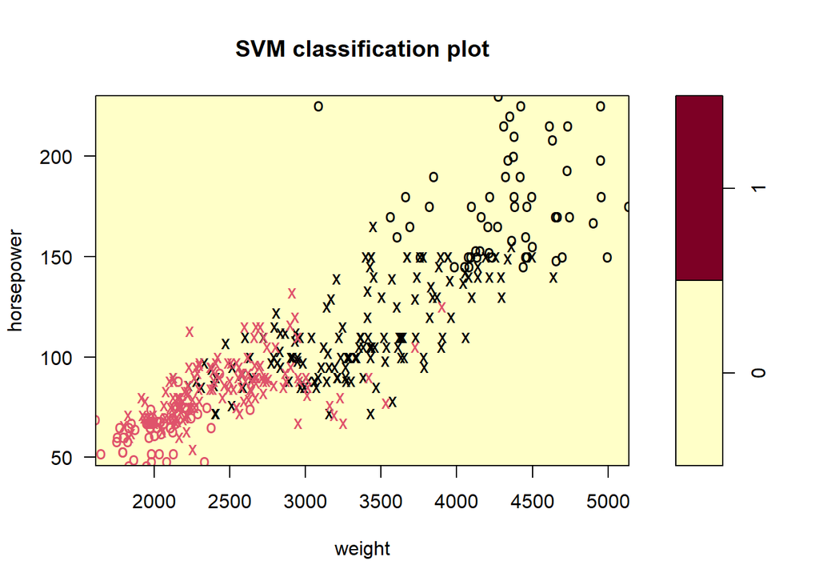

```r
plot(poly_Auto$best.model, Auto, horsepower ~ weight)
```

## 8

```r
set.seed(715)

index <- sample(nrow(OJ), 800)

train_oj <- OJ[index,]
test_oj <- OJ[-index,]
```

```r
oj_model_1 <- svm(Purchase ~., data= train_oj, kernel = "linear", cost = 0.01)
summary(oj_model_1)
```

```
##
## Call:
## svm(formula = Purchase ~ ., data = train_oj, kernel = "linear", cost = 0.01)
##
##
## Parameters:
##    SVM-Type:  C-classification
##  SVM-Kernel:  linear
##        cost:  0.01
##
## Number of Support Vectors:  437
##
##  ( 219 218 )
##
##
## Number of Classes:  2
##
## Levels:
##  CH MM
```

The linear model uses 437 support vectors which are nearly divided exactly in half. This seems like a large number of support vectors due to the face the training data only contains 800 data points.

```r
train_preds <- predict(oj_model_1, train_oj)
test_preds <- predict(oj_model_1, test_oj)

table(predictions = train_preds, train_response = train_oj$Purchase)
```

```
##            train_response
## predictions  CH  MM
##          CH 417  70
##          MM  65 248
```

```r
table(predictions = test_preds, train_response = test_oj$Purchase)
```

```
##            train_response
## predictions  CH  MM
##          CH 150  24
##          MM  21  75
```

Training Error Rate = 135 / 800 = 0.16875 or 16.875%.

```r
set.seed(715)

oj_linear<- tune(svm, Purchase ~ ., data = train_oj, kernel = "linear",
                 ranges = list(cost = c(0.01, 0.1, 1, 10)))

oj_linear$performances[which.min(oj_linear$performances$error),]
```

```
##   cost   error dispersion
## 4   10 0.16625 0.02703521
```

A cost of 10 gave the lowest error value.

```r
oj_linear_tuned <- svm(Purchase ~., data= train_oj, kernel = "linear", cost = 10)

train_preds <- predict(oj_linear_tuned, train_oj)
test_preds <- predict(oj_linear_tuned, test_oj)

table(predictions = train_preds, train_response = train_oj$Purchase)
```

```
##            train_response
## predictions  CH  MM
##          CH 421  66
##          MM  61 252
```

```r
table(predictions = test_preds, train_response = test_oj$Purchase)
```

```
##            train_response
## predictions  CH  MM
##          CH 150  23
##          MM  21  76
```

Training Error Rate: 127 / 800 = 0.15875 or 15.875%

Test Error Rate: 44 / 270 = 0.16296 or 16.296%

6. RADIAL

```r
oj_radial <- svm(Purchase ~., data= train_oj, kernel = "radial", cost = 0.01)
summary(oj_radial)
```

```
##
## Call:
## svm(formula = Purchase ~ ., data = train_oj, kernel = "radial", cost = 0.01)
##
##
## Parameters:
##    SVM-Type:  C-classification
##  SVM-Kernel:  radial
##        cost:  0.01
##
## Number of Support Vectors:  639
##
##  ( 321 318 )
##
##
## Number of Classes:  2
##
## Levels:
##  CH MM
```

The radial model uses 639 support vectors which is a significant increase from the linear model.

```r
train_preds <- predict(oj_radial, train_oj)
test_preds <- predict(oj_radial, test_oj)

table(predictions = train_preds, train_response = train_oj$Purchase)
```

```
##            train_response
## predictions  CH  MM
##          CH 482 318
##          MM   0   0
```

```r
table(predictions = test_preds, train_response = test_oj$Purchase)
```

```
##            train_response
## predictions  CH  MM
##          CH 171  99
##          MM   0   0
```

```r
set.seed(715)

oj_radial<- tune(svm, Purchase ~ ., data = train_oj, kernel = "radial",
                 ranges = list(cost = c(0.01, 0.1, 1, 10)))

oj_radial$performances[which.min(oj_radial$performances$error),]
```

```
##   cost  error dispersion
## 3    1 0.1775   0.033229
```

The optimal cost is 1.

```r
oj_radial_tuned <- svm(Purchase ~., data= train_oj, kernel = "radial", cost = 1)

train_preds <- predict(oj_radial_tuned, train_oj)
test_preds <- predict(oj_radial_tuned, test_oj)

table(predictions = train_preds, train_response = train_oj$Purchase)
```

```
##            train_response
## predictions  CH  MM
##          CH 435  76
##          MM  47 242
```

```r
table(predictions = test_preds, train_response = test_oj$Purchase)
```

```
##            train_response
## predictions  CH  MM
##          CH 156  29
##          MM  15  70
```

Training Error Rate: 123 / 800 = 0.15375 or 15.375% Test Error Rate: 44 / 270 = 0.16296 or 16.296%

```r
oj_poly <- svm(Purchase ~., data= train_oj, kernel = "polynomial", cost = 0.01, degree = 2)
summary(oj_poly)
```

```
##
## Call:
## svm(formula = Purchase ~ ., data = train_oj, kernel = "polynomial",
##     cost = 0.01, degree = 2)
##
##
## Parameters:
##    SVM-Type:  C-classification
##  SVM-Kernel:  polynomial
##        cost:  0.01
##      degree:  2
##      coef.0:  0
##
## Number of Support Vectors:  642
##
##  ( 324 318 )
##
##
## Number of Classes:  2
##
## Levels:
##  CH MM
```

The polynomial uses 642 support vectors which is a significant increase from the linear model.

```r
train_preds <- predict(oj_poly, train_oj)
test_preds <- predict(oj_poly, test_oj)

table(predictions = train_preds, train_response = train_oj$Purchase)
```

```
##            train_response
## predictions  CH  MM
##          CH 480 305
##          MM   2  13
```

```r
table(predictions = test_preds, train_response = test_oj$Purchase)
```

```
##            train_response
## predictions  CH  MM
##          CH 171  93
##          MM   0   6
```

Training Error Rate: 307 / 800 = .38375 or 38.375% Test Error Rate: 93 / 270 = .34444 or 34.444%

```r
set.seed(715)

oj_poly_2<- tune(svm, Purchase ~ ., data = train_oj, kernel = "polynomial", degree = 2,
                 ranges = list(cost = c(0.01, 0.1, 1, 10)))

oj_poly_2$performances[which.min(oj_poly_2$performances$error),]
```

```
##   cost error dispersion
## 4   10  0.18 0.03641962
```

The optimal cost for lower error is 10.

```r
oj_poly_tuned <- svm(Purchase ~., data= train_oj, kernel = "polynomial",degree =2 , cost = 10)

train_preds <- predict(oj_poly_tuned, train_oj)
test_preds <- predict(oj_poly_tuned, test_oj)

table(predictions = train_preds, train_response = train_oj$Purchase)
```

```
##            train_response
## predictions  CH  MM
##          CH 443  84
##          MM  39 234
```

```r
table(predictions = test_preds, train_response = test_oj$Purchase)
```

```
##            train_response
## predictions  CH  MM
##          CH 157  34
##          MM  14  65
```

Training Error Rate: 123 / 800 = 0.15375 or 15.375% Test Error Rate: 48 / 270 = 0.17778 or 17.778%

h

The best performing model considering test error rate is a two-way tie between a standard linear svm and radial both with a test error rate of 16.296%.